# Choroplethr Exploration of New York Health Data

Nate

September 28 2021

*Introduction* This is an example of using the choroplethr package to look at some NY state healthcare data.

The data sets used for this investigation were found on the New York state website. [data.ny.gov](https://data.ny.gov/browse?category=Health&utf8=%E2%9C%93)

Four different data sets were chosen:

- diabetic rates
- diabetic mortality rates
- average incomes by county
- obesity rates by county

*Data Manipulation and Visualization* Loading data

```r
library(dplyr)
library(ggplot2)
library(choroplethr)
library(choroplethrMaps)
library(readr)

Income <- readr::read_delim("https://raw.githubusercontent.com/catfoodlover/Data607/main/Income.csv", delim = ';', show_col_types = FALSE)
Mortality <- readr::read_delim("https://raw.githubusercontent.com/catfoodlover/Data607/main/Mortality.csv", delim = ';', show_col_types = FALSE)
Obese <- readr::read_delim("https://raw.githubusercontent.com/catfoodlover/Data607/main/Obese.csv", delim = ';', show_col_types = FALSE)
Diagnosed <- readr::read_delim("https://raw.githubusercontent.com/catfoodlover/Data607/main/Diagnosed.csv", delim = ';', show_col_types = FALSE)
```

Formatting data so the FIPS data can be joined in.

```r
data("county.regions")
Diagnosed <- rename(Diagnosed, County = "County Name")
Income <- rename(Income, County = "Place of Residence")
Income <- rename(Income, Year = "Tax Year")
Obese <- rename(Obese, County = "County Name")
Mortality <- rename(Mortality, County = "County Name")
Income$County <- as.character(Income$County)


Income <-mutate(Income, County=ifelse(County=="New York City - Bronx", "Bronx", County))
Income <-mutate(Income, County=ifelse(County=="New York City - Kings", "Kings", County))
Income <-mutate(Income, County=ifelse(County=="New York City - Manhattan", "New York", County))
Income <-mutate(Income, County=ifelse(County=="New York City - Queens", "Queens", County))
Income <-mutate(Income, County=ifelse(County=="New York City - Richmond", "Richmond", County))


Income09 <- filter(Income, Year == 2009)
Income09 <- mutate(Income09, County = ifelse(County == "new york city", "new york", County))


Obese$County <- tolower(Obese$County)
Income09$County <- tolower(Income09$County)
Mortality$County <- tolower(Mortality$County)
Diagnosed$County <- tolower(Diagnosed$County)


DiaDiagnosed <- filter(Diagnosed, Diagnosed$"Health Topic" %in% "Cirrhosis/Diabetes Indicators")


DiaDiagnosed <- rename(DiaDiagnosed, value = "Percent/Rate")
Mortality <- rename(Mortality, value = "Percentage/Rate")
Income09 <- rename(Income09, value = "Average NY AGI of All Returns")
Obese <- rename(Obese, value = "Percentage/Rate")


Test <- filter(county.regions, state.name %in% "new york")

#Income09 <- Income09 %>% mutate(County = as.character(County))

Test2 <- left_join(Test, Obese, by = c("county.name" = "County"))
Test3 <- left_join(Test, Income09, by = c("county.name" = "County"))
Test4 <- left_join(Test, DiaDiagnosed, by = c("county.name" = "County"))
Test5 <- left_join(Test, Mortality, by = c("county.name" = "County"))
```

Create choropleth maps for all my variables for New York and NYC.

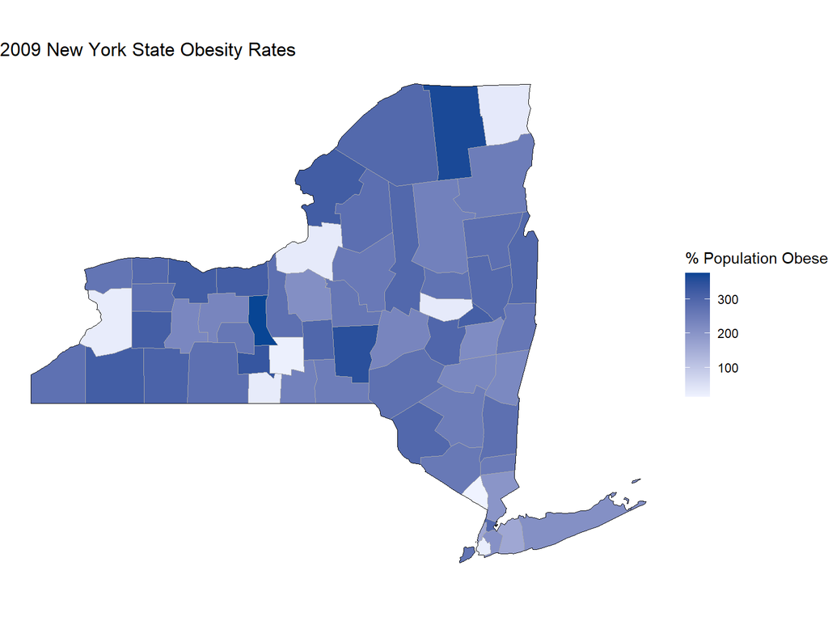

```r
county_choropleth(Test2,
                 title      = "2009 New York State Obesity Rates",
                 legend     = "% Population Obese",
                 num_colors = 1,
                 state_zoom = c("new york"))
```

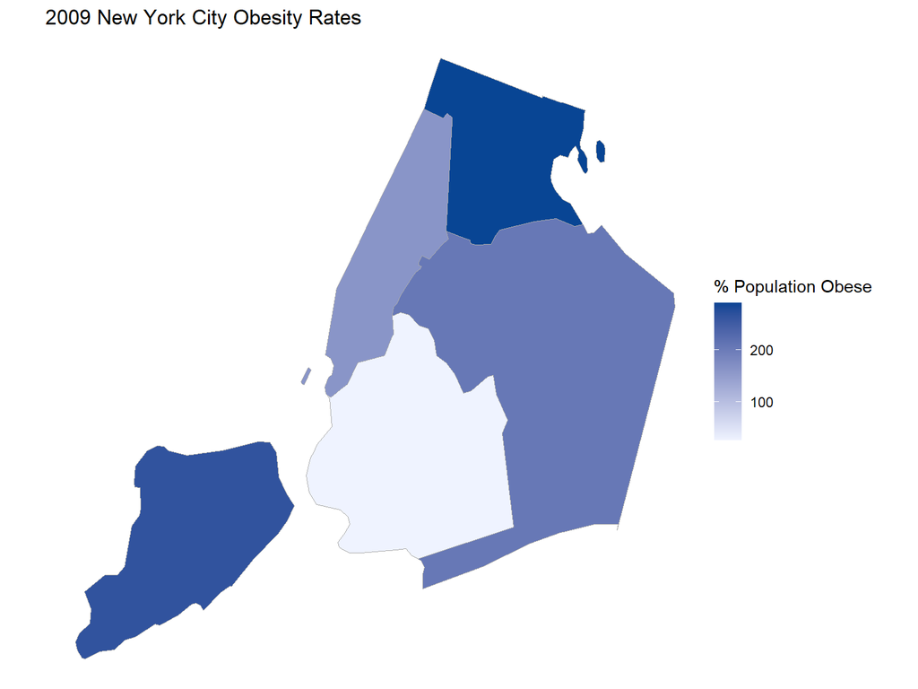

```r
new_york_city = c(36005, 36047, 36061, 36081, 36085)
county_choropleth(Test2,
                   title       = "2009 New York City Obesity Rates",
                   legend      = "% Population Obese",
                   num_colors  = 1,
                   county_zoom = new_york_city)
```

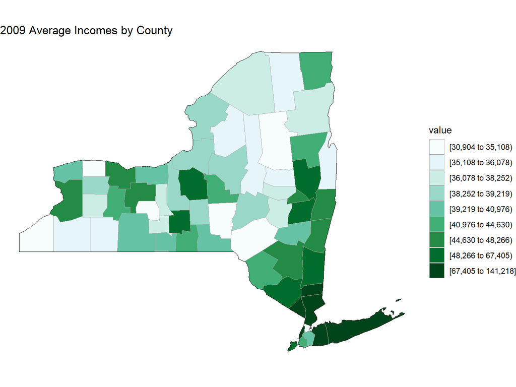

```r
county_choropleth(Test3,
                   title      = "2009 Average Incomes by County",
                   legend     = "Average Income in Thousands of $",
                   num_colors = 9,
                   state_zoom = c("new york")) + scale_fill_brewer(palette=2)
```

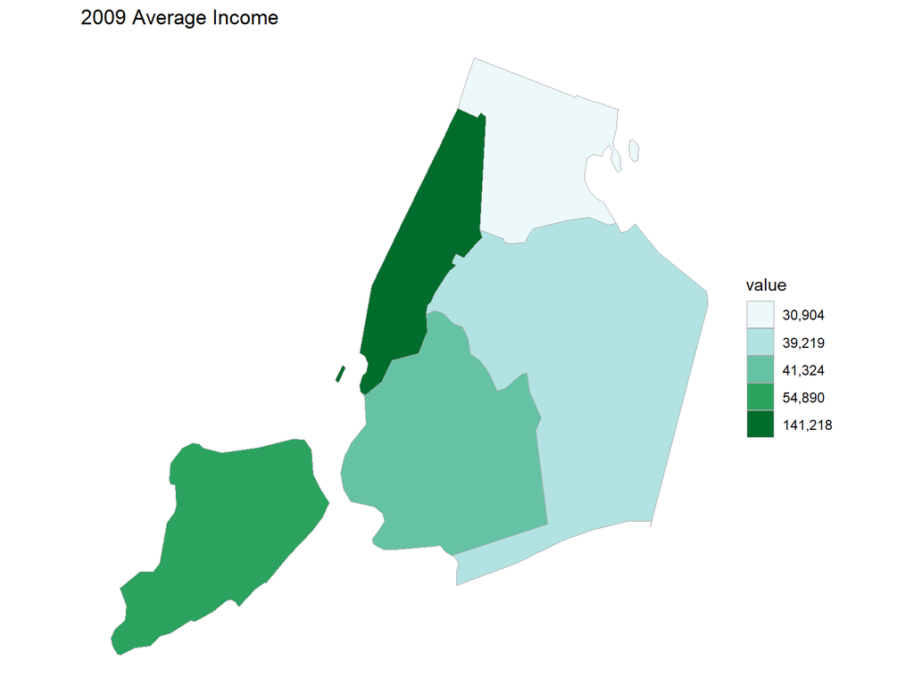

```r
new_york_city = c(36005, 36047, 36061, 36081, 36085)
county_choropleth(Test3,
                   title       = "2009 Average Income",
                   legend      = "Income in Thousands",
                   num_colors  = 9,
                   county_zoom = new_york_city)+scale_fill_brewer(palette=2)
```

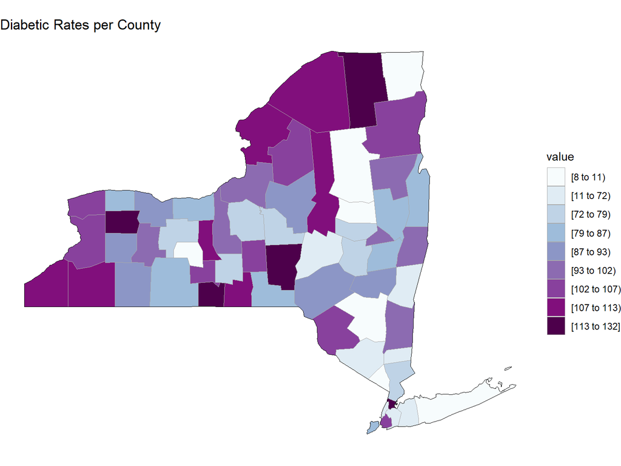

```r
county_choropleth(Test4,
                   title      = "Diabetic Rates per County",
                   legend     = "Percent of population with Diabetes",
                   num_colors = 9,
                   state_zoom = c("new york")) + scale_fill_brewer(palette=3)
```

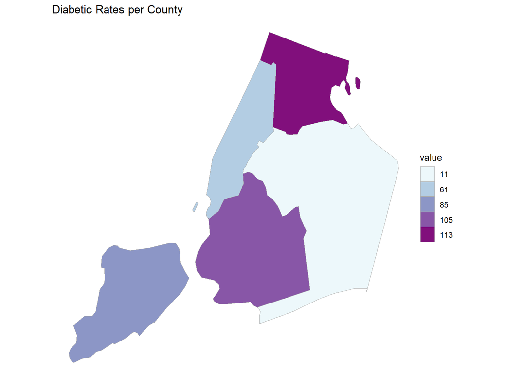

```r
new_york_city = c(36005, 36047, 36061, 36081, 36085)
county_choropleth(Test4,
                   title       = "Diabetic Rates per County",
                   legend      = "Percent of population with Diabetes",
                   num_colors  = 9,
                   county_zoom = new_york_city)+scale_fill_brewer(palette=3)
```

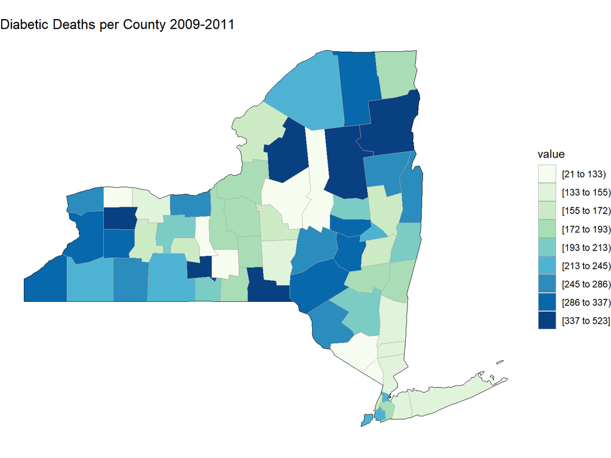

```r
county_choropleth(Test5,
                   title      = "Diabetic Deaths per County 2009-2011",
                   legend     = "Percent of Deaths Caused by Diabetes",
                   num_colors = 9,
                   state_zoom = c("new york")) + scale_fill_brewer(palette=4)
```

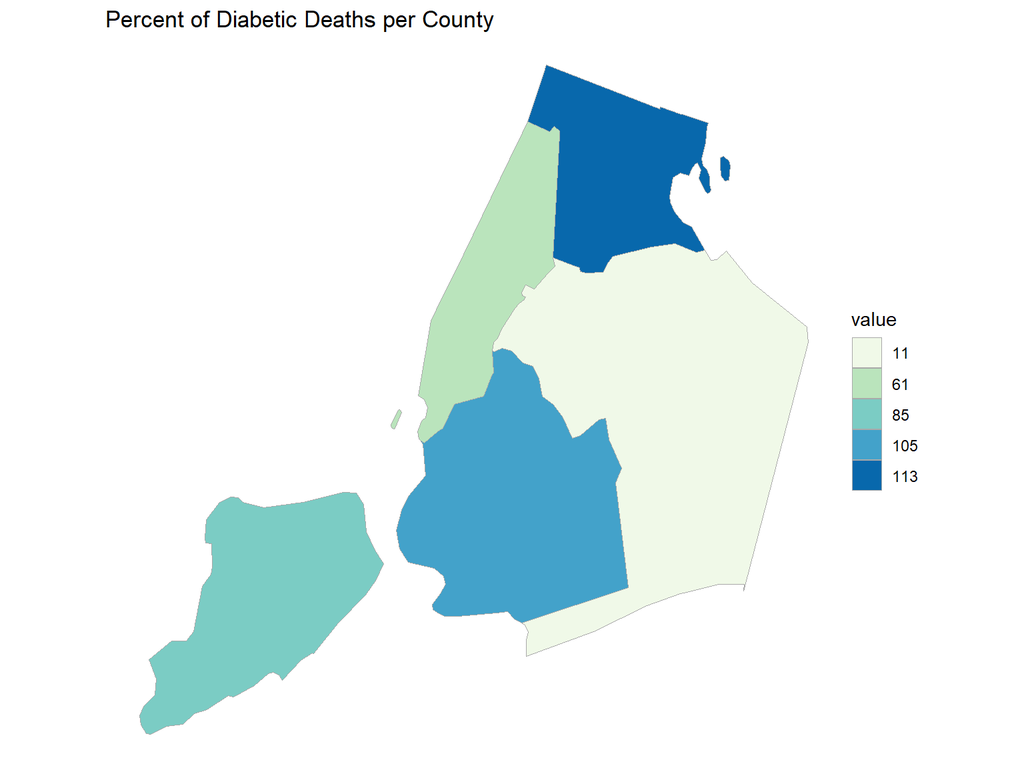

```r
new_york_city = c(36005, 36047, 36061, 36081, 36085)
county_choropleth(Test4,
                   title       = "Percent of Diabetic Deaths per County",
                   legend      = "Percent of Deaths Caused by Diabetes",
                   num_colors  = 9,
                   county_zoom = new_york_city)+scale_fill_brewer(palette=4)
```

Create scatter plots with loess regression line

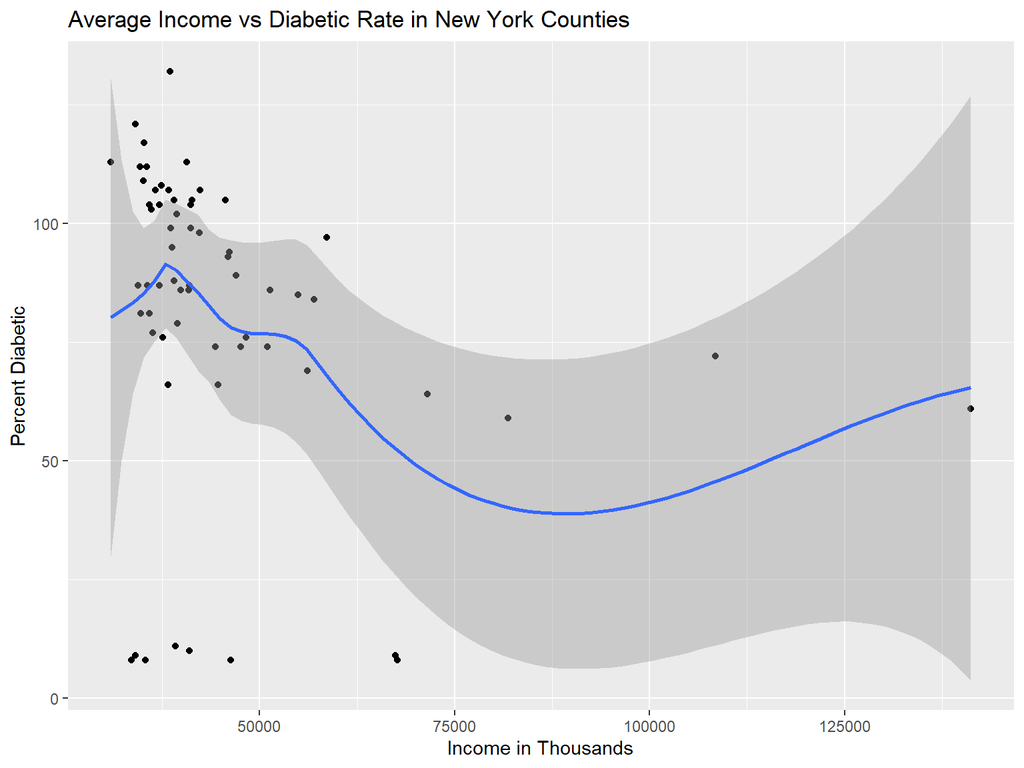

```r
qplot(Test3$value, Test4$value, xlab = "Income in Thousands", ylab = "Percent Diabetic",
 main = "Average Income vs Diabetic Rate in New York Counties") + (geom_smooth())
```

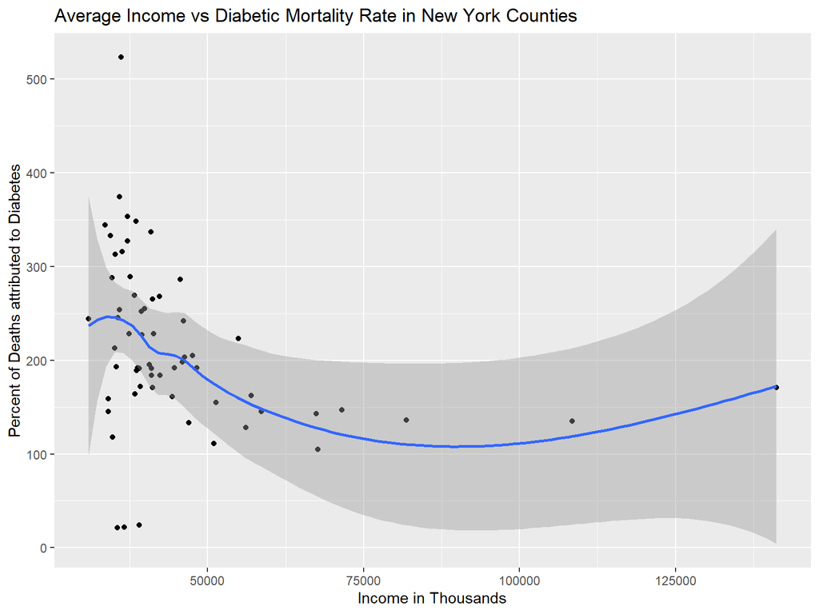

```r
qplot(Test3$value, Test5$value, xlab = "Income in Thousands", ylab = "Percent of Deaths attributed to Diabetes",
 main = "Average Income vs Diabetic Mortality Rate in New York Counties") + (geom_smooth())
```

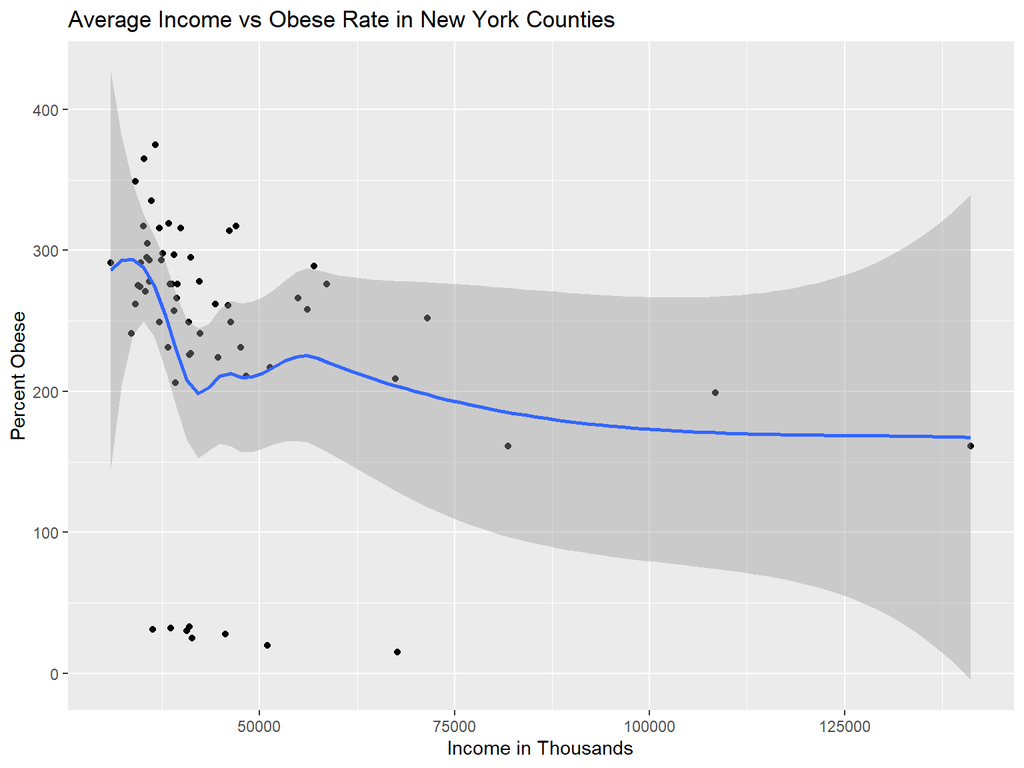

```r
qplot(Test3$value, Test2$value, xlab = "Income in Thousands", ylab = "Percent Obese",main = "Average Income vs Obese Rate in New York Counties") +
(geom_smooth())
```

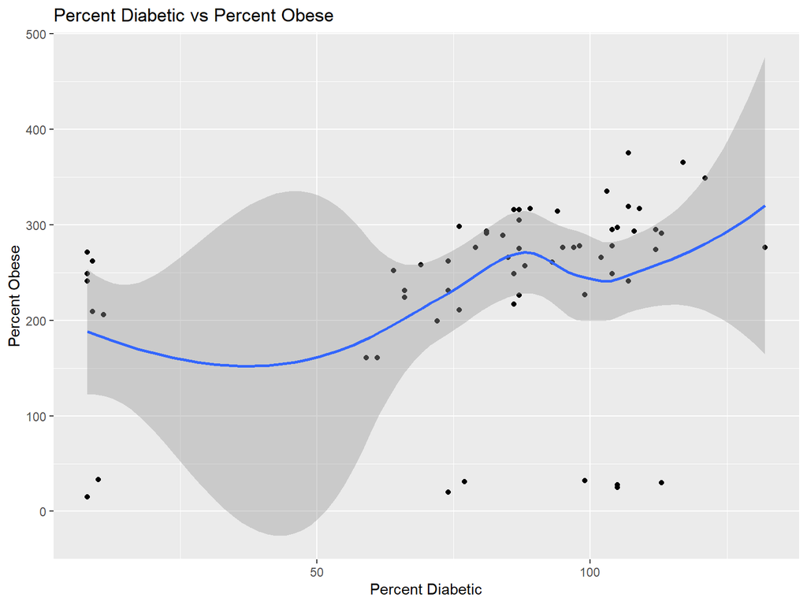

```r
qplot(Test4$value, Test2$value, xlab = "Percent Diabetic", ylab = "Percent Obese",main = "Percent Diabetic vs Percent Obese") +
(geom_smooth())
```

*Conclusion* Choroplethr is a great way to visualize data with a geographic component.

We found that there is a negative relationship income level and diabetic incidence.

There is also a positive relationship between obesity rates and diabetic rates.

The diabetic mortality rate unsurprisingly mirrors the diabetic incidence rate.

One interesting finding was that the while the Bronx was the poorest county it was not the county with the highest diabetic, obesity, or diabetic death rate.